# Prosody: Experiment 1

# Reading in data

```r
# setwd("/Users/seantrott/Dropbox/UCSD/Research/IndirectSpeechActs/Prosody/pros_scaled/src/analysis/exp1/")
df_critical = read.csv("../../../data/processed/exp1/exp1.csv")
```

## Checking over data

```r
length(unique(df_critical$subject))
```

```
## [1] 76
```

```r
table(df_critical$speaker, df_critical$condition)
```

```
##
##      Non-Request Request
##   S1         456     456
##   S2         456     456
##   S3         456     456
##   S4         456     456
##   S5         456     456
```

## Merge with norming data

```r
df_normed = read_csv("../../../data/processed/norming/item_means.csv")
df_merged = df_critical %>%
  inner_join(df_normed, by = c("stimNum", "form", "topic"))

nrow(df_critical)
```

```
## [1] 4560
```

```r
nrow(df_merged)
```

```
## [1] 4560
```

```r
df_merged = df_merged %>%
  mutate(Intent = condition)
```

# Primary analyses

## Q1: Does Intent predict response?

### Descriptive

```r
mean(df_merged$correct)
```

```
## [1] 0.6087719
```

```r
df_merged %>%
  group_by(Intent) %>%
  summarise(mean_request = mean(numeric_response))
```

```
## # A tibble: 2 x 2
##   Intent      mean_request
##   <fct>              <dbl>
## 1 Non-Request        0.332
## 2 Request            0.550
```

```r
df_merged %>%
  group_by(form, Intent) %>%
  summarise(mean_request = mean(numeric_response))
```

```
## # A tibble: 4 x 3
## # Groups:   form [2]
##   form            Intent      mean_request
##   <chr>           <fct>              <dbl>
## 1 conventional    Non-Request        0.481
## 2 conventional    Request            0.754
## 3 nonconventional Non-Request        0.198
## 4 nonconventional Request            0.366
```

### Visualization

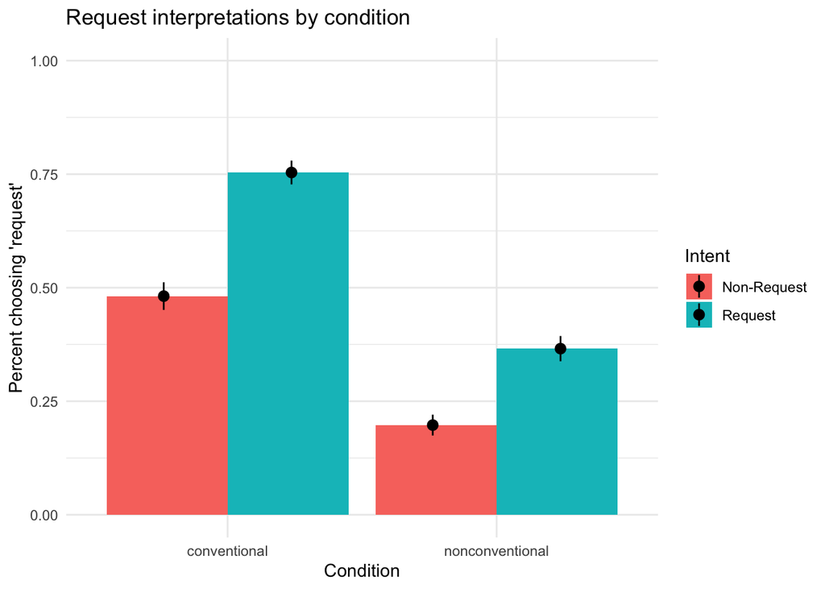

```r
df_merged %>%
  ggplot(aes(x = form, y = numeric_response, fill = Intent)) +
  geom_bar(stat="summary", position="dodge", fun="mean") +
  stat_summary (fun = function(x){mean(x)},
                fun.min = function(x){mean(x) - 2*sd(x)/sqrt(length(x))},
                fun.max = function(x){mean(x) + 2*sd(x)/sqrt(length(x))},
                geom= 'pointrange',
                position=position_dodge(width=0.95)) +
  theme_minimal() +
  ggtitle("Request interpretations by condition") +
  xlab("Condition") +
  ylab("Percent choosing 'request'") +
  scale_y_continuous(limits = c(0, 1))
```

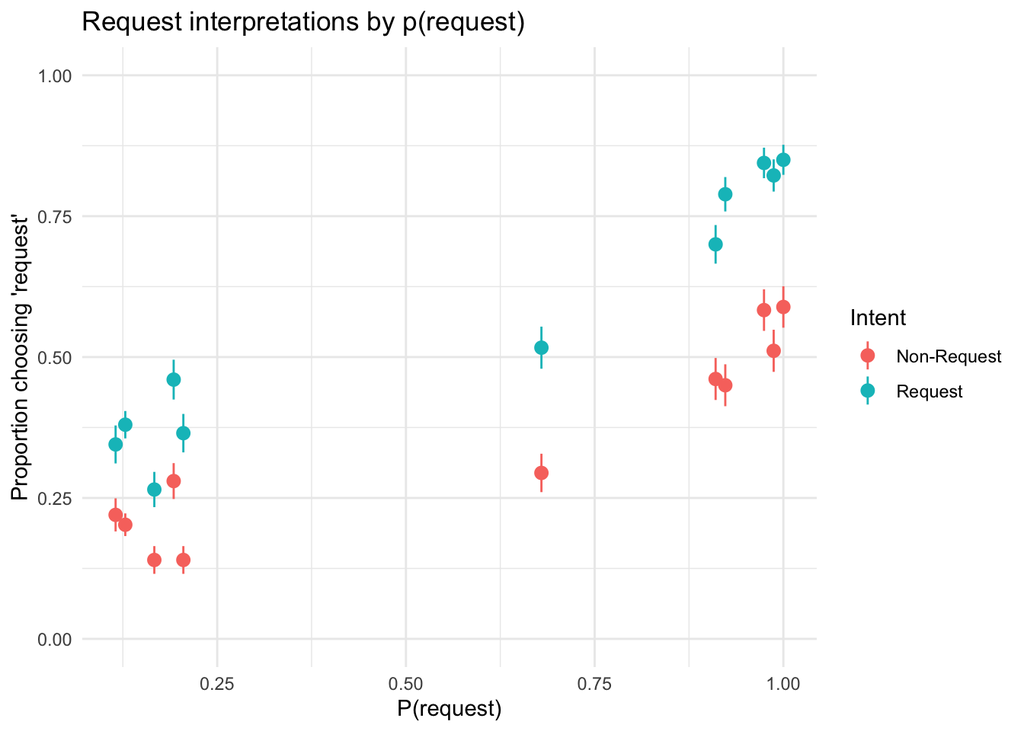

```r
df_merged %>%
  ggplot(aes(x = mean_request,
             y = numeric_response,
             color = Intent)) +
  stat_summary (fun = function(x){mean(x)},
                fun.min = function(x){mean(x) - 1*sd(x)/sqrt(length(x))},
                fun.max = function(x){mean(x) + 1*sd(x)/sqrt(length(x))},
                geom= 'pointrange') +
  theme_minimal() +
  ggtitle("Request interpretations by p(request)") +
  xlab("P(request)") +
  ylab("Proportion choosing 'request'") +
  scale_y_continuous(limits = c(0, 1))
```

### Analysis

We ask whether `Intent` explains variance in `Response`, above and beyond other factors like `Prior request probability` and `Form`.

```r
model_full = glmer(data=df_merged,
                response ~ Intent + form + mean_request +
                  (1 + Intent | topic) +
             (1 + Intent + mean_request | subject) +
               (1 | speaker),
           control=glmerControl(optimizer="bobyqa"),
         family=binomial())
```

```
## boundary (singular) fit: see ?isSingular
```

```r
summary(model_full)
```

```
## Generalized linear mixed model fit by maximum likelihood (Laplace
##   Approximation) [glmerMod]
##  Family: binomial  ( logit )
## Formula: response ~ Intent + form + mean_request + (1 + Intent | topic) +
##     (1 + Intent + mean_request | subject) + (1 | speaker)
##    Data: df_merged
## Control: glmerControl(optimizer = "bobyqa")
##
##      AIC      BIC   logLik deviance df.resid
##   4759.3   4849.2  -2365.6   4731.3     4546
##
## Scaled residuals:
##     Min      1Q  Median      3Q     Max
## -3.6676 -0.6319 -0.1254  0.6807  4.4483
##
## Random effects:
##  Groups  Name          Variance Std.Dev. Corr
##  subject (Intercept)   6.93726  2.63387
##          IntentRequest 0.55447  0.74463  -0.76
##          mean_request  6.16730  2.48341  -0.98  0.75
##  topic   (Intercept)   0.11178  0.33434
##          IntentRequest 0.00224  0.04732  -1.00
##  speaker (Intercept)   0.07632  0.27626
## Number of obs: 4560, groups:  subject, 76; topic, 12; speaker, 5
##
## Fixed effects:
##                     Estimate Std. Error z value Pr(>|z|)
## (Intercept)          -4.6851     1.3556  -3.456 0.000548 ***
## IntentRequest         1.4073     0.1235  11.393  < 2e-16 ***
## formnonconventional   1.4992     1.1389   1.316 0.188038
## mean_request          5.0332     1.4601   3.447 0.000566 ***
## ---
## Signif. codes:  0 '***' 0.001 '**' 0.01 '*' 0.05 '.' 0.1 ' ' 1
##
## Correlation of Fixed Effects:
##             (Intr) IntntR frmnnc
## IntentReqst -0.222
## frmnncnvntn -0.948  0.067
## mean_requst -0.987  0.180  0.947
## convergence code: 0
## boundary (singular) fit: see ?isSingular
```

```r
model_no_intent = glmer(data=df_merged,
                response ~ form + mean_request +
                  (1 + Intent | topic) +
             (1 + Intent + mean_request | subject) +
               (1 | speaker),
           control=glmerControl(optimizer="bobyqa"),
         family=binomial())


anova(model_full, model_no_intent)
```

```
## Data: df_merged
## Models:
## model_no_intent: response ~ form + mean_request + (1 + Intent | topic) + (1 +
## model_no_intent:     Intent + mean_request | subject) + (1 | speaker)
## model_full: response ~ Intent + form + mean_request + (1 + Intent | topic) +
## model_full:     (1 + Intent + mean_request | subject) + (1 | speaker)
##                 npar    AIC    BIC  logLik deviance  Chisq Df Pr(>Chisq)
## model_no_intent   13 4798.0 4881.5 -2386.0   4772.0
## model_full        14 4759.3 4849.2 -2365.6   4731.3 40.752  1  1.728e-10 ***
## ---
## Signif. codes:  0 '***' 0.001 '**' 0.01 '*' 0.05 '.' 0.1 ' ' 1
```

We can also visualize the coefficients from this model:

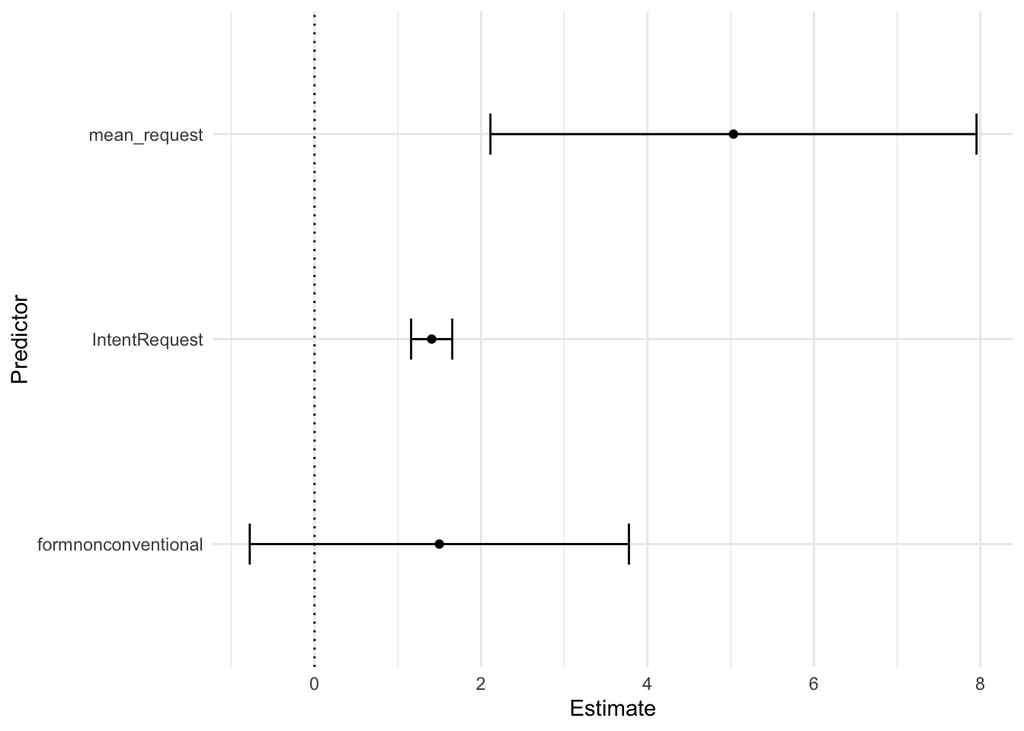

```r
df_tidy = broom.mixed::tidy(model_full)

df_tidy %>%
  filter(effect == "fixed") %>%
  filter(term != "(Intercept)") %>%
  ggplot(aes(x = term,
             y = estimate)) +
  geom_point() +
  coord_flip() +
  geom_hline(yintercept = 0, linetype = "dotted") +
  geom_errorbar(aes(ymin = estimate - 2*std.error,
                    ymax = estimate + 2*std.error),
                width=.2,
                position=position_dodge(.9)) +
  labs(x = "Predictor",
       y = "Estimate") +
  theme_minimal()
```

### Characterize respective effect sizes

We'd also like to understand the **contribution** of each of these sources of information. Here, we follow the approach in Brysbaert & Stevens (2018).

**TODO**: Double-check this.

```r
slope_intent = filter(df_tidy, term == "IntentRequest")$estimate
slope_form = filter(df_tidy, term == "formnonconventional")$estimate
slope_prior = filter(df_tidy, term == "mean_request")$estimate

var_re = sum(filter(df_tidy, effect == "ran_pars")$estimate**2)

slope_intent / sqrt(var_re)
```

```
## [1] 0.3418784
```

```r
slope_form / sqrt(var_re)
```

```
## [1] 0.364209
```

```r
slope_prior / sqrt(var_re)
```

```
## [1] 1.222727
```

## Which acoustic features predict pragmatic interpretation?

### Load acoustic features data

```r
df_audio = read_csv("../../../data/processed/audio/audio_features_original_stimuli.csv")
df_audio$label = factor(df_audio$label)

df_audio$condition = fct_recode(df_audio$label,
                            "Request" = "ir",
                            "Non-Request" = "literal")

df_audio$speaker = factor(df_audio$speaker)

df_audio = df_audio %>%
  group_by(speaker) %>%
  mutate(mean_f0_z_score = scale(mean_f0),
         duration_f0_z_score = scale(duration_f0),
         range_f0_z_score = scale(range_f0),
         sd_f0_z_score = scale(sd_f0),
         slope_f0_z_score = scale(slope_f0),
         mean_intensity_z_score = scale(mean_intensity),
         sd_intensity_z_score = scale(sd_intensity)
         )
```

### Merge with behavioral data

```r
df_audio = df_audio %>%
  select(condition, speaker, stimNum, mean_f0_z_score, duration_f0_z_score, range_f0_z_score,
         sd_f0_z_score, slope_f0_z_score, mean_intensity_z_score, sd_intensity_z_score)
nrow(df_audio)
```

```
## [1] 120
```

```r
df_merged_audio = df_merged %>%
  inner_join(df_audio, on = c("condition", "speaker", "stimNum"))
nrow(df_merged_audio)
```

```
## [1] 4560
```

```r
df_merged_audio$response = fct_recode(df_merged_audio$response,
                             "Request" = "request",
                             "Non-Request" = "literal")
# df_merged_audio$response = factor(df_merged_audio$response, levels=c("Request", "Non-Request"))
df_merged_audio$form = factor(df_merged_audio$form, levels=c("nonconventional", "conventional"))
```

### Analysis

Now we ask whether adding acoustic features to the model predicts participants' **responses**, above and beyond the variance explained by *form* and *speaker* (and their interaction).

To do this, we compare each model in turn, successively dropping out different acoustic features.

Random effects include random intercepts for subjects and items. Including a random slope for the effect of form for items (as in the models above) prevents the models from converging. (That said, analysis of these models suggests very similar results.)

### Do the features predict participants' predicted label?

```r
model_response_full = glmer(data = df_merged_audio,
                      response ~ slope_f0_z_score * form +
                        mean_f0_z_score * form +
                       duration_f0_z_score * form +
                       range_f0_z_score * form +
                       sd_f0_z_score * form +
                       mean_intensity_z_score * form +
                       sd_intensity_z_score * form +
                        (1 | subject) +
                        (1 | speaker) +
                        (1 | stimNum),
                       control=glmerControl(optimizer="bobyqa"),
                       family = binomial())


summary(model_response_full)
```

```
## Generalized linear mixed model fit by maximum likelihood (Laplace
##   Approximation) [glmerMod]
##  Family: binomial  ( logit )
## Formula: response ~ slope_f0_z_score * form + mean_f0_z_score * form +
##     duration_f0_z_score * form + range_f0_z_score * form + sd_f0_z_score *
##     form + mean_intensity_z_score * form + sd_intensity_z_score *
##     form + (1 | subject) + (1 | speaker) + (1 | stimNum)
##    Data: df_merged_audio
## Control: glmerControl(optimizer = "bobyqa")
##
##      AIC      BIC   logLik deviance df.resid
##   4841.0   4963.1  -2401.5   4803.0     4541
##
## Scaled residuals:
##     Min      1Q  Median      3Q     Max
## -7.1954 -0.6352 -0.1685  0.6631  6.8932
##
## Random effects:
##  Groups  Name        Variance Std.Dev.
##  subject (Intercept) 1.44295  1.2012
##  stimNum (Intercept) 0.29136  0.5398
##  speaker (Intercept) 0.01878  0.1371
## Number of obs: 4560, groups:  subject, 76; stimNum, 12; speaker, 5
##
## Fixed effects:
##                                         Estimate Std. Error z value Pr(>|z|)
## (Intercept)                             -1.19491    0.30822  -3.877 0.000106
## slope_f0_z_score                         0.28422    0.09391   3.026 0.002475
## formconventional                         1.96004    0.42820   4.577 4.71e-06
## mean_f0_z_score                          0.48107    0.13881   3.466 0.000529
## duration_f0_z_score                      0.56435    0.07851   7.188 6.55e-13
## range_f0_z_score                         0.07335    0.16067   0.457 0.648018
## sd_f0_z_score                           -0.24285    0.20603  -1.179 0.238507
## mean_intensity_z_score                   0.20604    0.06294   3.274 0.001061
## sd_intensity_z_score                    -0.12992    0.06896  -1.884 0.059559
## slope_f0_z_score:formconventional       -0.74200    0.11505  -6.449 1.13e-10
## formconventional:mean_f0_z_score        -0.53865    0.15848  -3.399 0.000677
## formconventional:duration_f0_z_score    -1.27491    0.10982 -11.609  < 2e-16
## formconventional:range_f0_z_score        0.10767    0.21289   0.506 0.613038
## formconventional:sd_f0_z_score           0.08989    0.25593   0.351 0.725419
## formconventional:mean_intensity_z_score -0.15068    0.08747  -1.723 0.084958
## formconventional:sd_intensity_z_score    0.10489    0.09517   1.102 0.270380
##
## (Intercept)                             ***
## slope_f0_z_score                        **
## formconventional                        ***
## mean_f0_z_score                         ***
## duration_f0_z_score                     ***
## range_f0_z_score
## sd_f0_z_score
## mean_intensity_z_score                  **
## sd_intensity_z_score                    .
## slope_f0_z_score:formconventional       ***
## formconventional:mean_f0_z_score        ***
## formconventional:duration_f0_z_score    ***
## formconventional:range_f0_z_score
## formconventional:sd_f0_z_score
## formconventional:mean_intensity_z_score .
## formconventional:sd_intensity_z_score
## ---
## Signif. codes:  0 '***' 0.001 '**' 0.01 '*' 0.05 '.' 0.1 ' ' 1
```

```
##
## Correlation matrix not shown by default, as p = 16 > 12.
## Use print(x, correlation=TRUE)  or
##     vcov(x)        if you need it
```

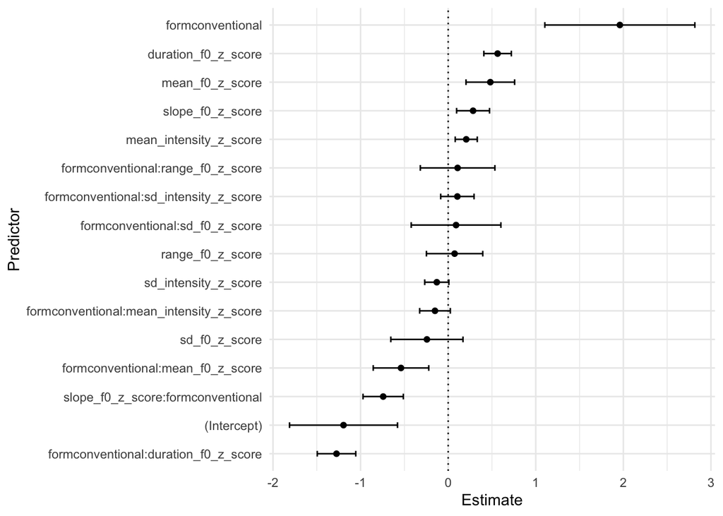

```r
df_tidy = broom.mixed::tidy(model_response_full)

df_tidy %>%
  filter(effect == "fixed") %>%
  ggplot(aes(x = reorder(term, estimate),
             y = estimate)) +
  geom_point() +
  coord_flip() +
  geom_hline(yintercept = 0, linetype = "dotted") +
  geom_errorbar(aes(ymin = estimate - 2*std.error,
                    ymax = estimate + 2*std.error),
                width=.2,
                position=position_dodge(.9)) +
  labs(x = "Predictor",
       y = "Estimate") +
  theme_minimal()
```

#### F0 slope

```r
model_response_no_slope_interaction = glmer(data = df_merged_audio,
                      response ~ slope_f0_z_score +
                      mean_f0_z_score * form +
                      duration_f0_z_score * form +
                       range_f0_z_score * form +
                       sd_f0_z_score * form +
                       mean_intensity_z_score * form +
                       sd_intensity_z_score * form +
                        (1 | subject) +
                        (1 | speaker) +
                        (1 | stimNum),
                       control=glmerControl(optimizer="bobyqa"),
                       family = binomial())

model_response_no_slope = glmer(data = df_merged_audio,
                      response ~ mean_f0_z_score * form +
                       duration_f0_z_score * form +
                       range_f0_z_score * form +
                       sd_f0_z_score * form +
                       mean_intensity_z_score * form +
                       sd_intensity_z_score * form +
                        (1 | subject) +
                        (1 | speaker) +
                        (1 | stimNum),
                       control=glmerControl(optimizer="bobyqa"),
                       family = binomial())
```

```r
anova(model_response_full, model_response_no_slope_interaction)
```

```
## Data: df_merged_audio
## Models:
## model_response_no_slope_interaction: response ~ slope_f0_z_score + mean_f0_z_score * form + duration_f0_z_score *
## model_response_no_slope_interaction:     form + range_f0_z_score * form + sd_f0_z_score * form + mean_intensity_z_score *
## model_response_no_slope_interaction:     form + sd_intensity_z_score * form + (1 | subject) + (1 |
## model_response_no_slope_interaction:     speaker) + (1 | stimNum)
## model_response_full: response ~ slope_f0_z_score * form + mean_f0_z_score * form +
## model_response_full:     duration_f0_z_score * form + range_f0_z_score * form + sd_f0_z_score *
## model_response_full:     form + mean_intensity_z_score * form + sd_intensity_z_score *
## model_response_full:     form + (1 | subject) + (1 | speaker) + (1 | stimNum)
##                                     npar    AIC    BIC  logLik deviance  Chisq
## model_response_no_slope_interaction   18 4882.3 4998.0 -2423.2   4846.3
## model_response_full                   19 4841.0 4963.1 -2401.5   4803.0 43.319
##                                     Df Pr(>Chisq)
## model_response_no_slope_interaction
## model_response_full                  1  4.652e-11 ***
## ---
## Signif. codes:  0 '***' 0.001 '**' 0.01 '*' 0.05 '.' 0.1 ' ' 1
```

```r
anova(model_response_no_slope_interaction, model_response_no_slope)
```

```
## Data: df_merged_audio
## Models:
## model_response_no_slope: response ~ mean_f0_z_score * form + duration_f0_z_score * form +
## model_response_no_slope:     range_f0_z_score * form + sd_f0_z_score * form + mean_intensity_z_score *
## model_response_no_slope:     form + sd_intensity_z_score * form + (1 | subject) + (1 |
## model_response_no_slope:     speaker) + (1 | stimNum)
## model_response_no_slope_interaction: response ~ slope_f0_z_score + mean_f0_z_score * form + duration_f0_z_score *
## model_response_no_slope_interaction:     form + range_f0_z_score * form + sd_f0_z_score * form + mean_intensity_z_score *
## model_response_no_slope_interaction:     form + sd_intensity_z_score * form + (1 | subject) + (1 |
## model_response_no_slope_interaction:     speaker) + (1 | stimNum)
##                                     npar    AIC    BIC  logLik deviance Chisq
## model_response_no_slope               17 4896.5 5005.7 -2431.2   4862.5
## model_response_no_slope_interaction   18 4882.3 4998.0 -2423.2   4846.3 16.15
##                                     Df Pr(>Chisq)
## model_response_no_slope
## model_response_no_slope_interaction  1  5.853e-05 ***
## ---
## Signif. codes:  0 '***' 0.001 '**' 0.01 '*' 0.05 '.' 0.1 ' ' 1
```

#### Mean F0

```r
model_response_no_mean_f0_interaction = glmer(data = df_merged_audio,
                      response ~ slope_f0_z_score * form +
                        mean_f0_z_score +
                       duration_f0_z_score * form +
                       range_f0_z_score * form +
                       sd_f0_z_score * form +
                       mean_intensity_z_score * form +
                       sd_intensity_z_score * form +
                        (1 | subject) +
                        (1 | speaker) +
                        (1 | stimNum),
                       control=glmerControl(optimizer="bobyqa"),
                       family = binomial())

model_response_no_mean_f0 = glmer(data = df_merged_audio,
                      response ~ slope_f0_z_score * form +
                       duration_f0_z_score * form +
                       range_f0_z_score * form +
                       sd_f0_z_score * form +
                       mean_intensity_z_score * form +
                       sd_intensity_z_score * form +
                        (1 | subject) +
                        (1 | speaker) +
                        (1 | stimNum),
                       control=glmerControl(optimizer="bobyqa"),
                       family = binomial())
```

```r
anova(model_response_full, model_response_no_mean_f0_interaction)
```

```
## Data: df_merged_audio
## Models:
## model_response_no_mean_f0_interaction: response ~ slope_f0_z_score * form + mean_f0_z_score + duration_f0_z_score *
## model_response_no_mean_f0_interaction:     form + range_f0_z_score * form + sd_f0_z_score * form + mean_intensity_z_score *
## model_response_no_mean_f0_interaction:     form + sd_intensity_z_score * form + (1 | subject) + (1 |
## model_response_no_mean_f0_interaction:     speaker) + (1 | stimNum)
## model_response_full: response ~ slope_f0_z_score * form + mean_f0_z_score * form +
## model_response_full:     duration_f0_z_score * form + range_f0_z_score * form + sd_f0_z_score *
## model_response_full:     form + mean_intensity_z_score * form + sd_intensity_z_score *
## model_response_full:     form + (1 | subject) + (1 | speaker) + (1 | stimNum)
##                                       npar    AIC    BIC  logLik deviance
## model_response_no_mean_f0_interaction   18 4850.4 4966.1 -2407.2   4814.4
## model_response_full                     19 4841.0 4963.1 -2401.5   4803.0
##                                        Chisq Df Pr(>Chisq)
## model_response_no_mean_f0_interaction
## model_response_full                   11.461  1  0.0007107 ***
## ---
## Signif. codes:  0 '***' 0.001 '**' 0.01 '*' 0.05 '.' 0.1 ' ' 1
```

```r
anova(model_response_no_mean_f0_interaction, model_response_no_mean_f0)
```

```
## Data: df_merged_audio
## Models:
## model_response_no_mean_f0: response ~ slope_f0_z_score * form + duration_f0_z_score * form +
## model_response_no_mean_f0:     range_f0_z_score * form + sd_f0_z_score * form + mean_intensity_z_score *
## model_response_no_mean_f0:     form + sd_intensity_z_score * form + (1 | subject) + (1 |
## model_response_no_mean_f0:     speaker) + (1 | stimNum)
## model_response_no_mean_f0_interaction: response ~ slope_f0_z_score * form + mean_f0_z_score + duration_f0_z_score *
## model_response_no_mean_f0_interaction:     form + range_f0_z_score * form + sd_f0_z_score * form + mean_intensity_z_score *
## model_response_no_mean_f0_interaction:     form + sd_intensity_z_score * form + (1 | subject) + (1 |
## model_response_no_mean_f0_interaction:     speaker) + (1 | stimNum)
##                                       npar    AIC    BIC  logLik deviance
## model_response_no_mean_f0               17 4849.4 4958.6 -2407.7   4815.4
## model_response_no_mean_f0_interaction   18 4850.4 4966.1 -2407.2   4814.4
##                                        Chisq Df Pr(>Chisq)
## model_response_no_mean_f0
## model_response_no_mean_f0_interaction 0.9544  1     0.3286
```

#### F0 duration (number of voiced frames)

```r
model_response_no_f0_dur_interaction = glmer(data = df_merged_audio,
                      response ~ slope_f0_z_score * form +
                        mean_f0_z_score * form +
                       duration_f0_z_score +
                       range_f0_z_score * form +
                       sd_f0_z_score * form +
                       mean_intensity_z_score * form +
                       sd_intensity_z_score * form +
                        (1 | subject) +
                        (1 | speaker) +
                        (1 | stimNum),
                       control=glmerControl(optimizer="bobyqa"),
                       family = binomial())

model_response_no_f0_dur = glmer(data = df_merged_audio,
                      response ~ slope_f0_z_score * form +
                        mean_f0_z_score * form +
                       range_f0_z_score * form +
                       sd_f0_z_score * form +
                       mean_intensity_z_score * form +
                       sd_intensity_z_score * form +
                        (1 | subject) +
                        (1 | speaker) +
                        (1 | stimNum),
                       control=glmerControl(optimizer="bobyqa"),
                       family = binomial())
```

```r
anova(model_response_full, model_response_no_f0_dur_interaction)
```

```
## Data: df_merged_audio
## Models:
## model_response_no_f0_dur_interaction: response ~ slope_f0_z_score * form + mean_f0_z_score * form +
## model_response_no_f0_dur_interaction:     duration_f0_z_score + range_f0_z_score * form + sd_f0_z_score *
## model_response_no_f0_dur_interaction:     form + mean_intensity_z_score * form + sd_intensity_z_score *
## model_response_no_f0_dur_interaction:     form + (1 | subject) + (1 | speaker) + (1 | stimNum)
## model_response_full: response ~ slope_f0_z_score * form + mean_f0_z_score * form +
## model_response_full:     duration_f0_z_score * form + range_f0_z_score * form + sd_f0_z_score *
## model_response_full:     form + mean_intensity_z_score * form + sd_intensity_z_score *
## model_response_full:     form + (1 | subject) + (1 | speaker) + (1 | stimNum)
##                                      npar    AIC    BIC  logLik deviance  Chisq
## model_response_no_f0_dur_interaction   18 4982.6 5098.3 -2473.3   4946.6
## model_response_full                    19 4841.0 4963.1 -2401.5   4803.0 143.64
##                                      Df Pr(>Chisq)
## model_response_no_f0_dur_interaction
## model_response_full                   1  < 2.2e-16 ***
## ---
## Signif. codes:  0 '***' 0.001 '**' 0.01 '*' 0.05 '.' 0.1 ' ' 1
```

```r
anova(model_response_no_f0_dur_interaction, model_response_no_f0_dur)
```

```
## Data: df_merged_audio
## Models:
## model_response_no_f0_dur: response ~ slope_f0_z_score * form + mean_f0_z_score * form +
## model_response_no_f0_dur:     range_f0_z_score * form + sd_f0_z_score * form + mean_intensity_z_score *
## model_response_no_f0_dur:     form + sd_intensity_z_score * form + (1 | subject) + (1 |
## model_response_no_f0_dur:     speaker) + (1 | stimNum)
## model_response_no_f0_dur_interaction: response ~ slope_f0_z_score * form + mean_f0_z_score * form +
## model_response_no_f0_dur_interaction:     duration_f0_z_score + range_f0_z_score * form + sd_f0_z_score *
## model_response_no_f0_dur_interaction:     form + mean_intensity_z_score * form + sd_intensity_z_score *
## model_response_no_f0_dur_interaction:     form + (1 | subject) + (1 | speaker) + (1 | stimNum)
##                                      npar    AIC    BIC  logLik deviance  Chisq
## model_response_no_f0_dur               17 4984.7 5094.0 -2475.4   4950.7
## model_response_no_f0_dur_interaction   18 4982.6 5098.3 -2473.3   4946.6 4.1147
##                                      Df Pr(>Chisq)
## model_response_no_f0_dur
## model_response_no_f0_dur_interaction  1    0.04251 *
## ---
## Signif. codes:  0 '***' 0.001 '**' 0.01 '*' 0.05 '.' 0.1 ' ' 1
```

#### F0 range

```r
model_response_no_f0_range_interaction = glmer(data = df_merged_audio,
                      response ~ slope_f0_z_score * form +
                        mean_f0_z_score * form +
                       duration_f0_z_score * form +
                       range_f0_z_score +
                       sd_f0_z_score * form +
                       mean_intensity_z_score * form +
                       sd_intensity_z_score * form +
                        (1 | subject) +
                        (1 | speaker) +
                        (1 | stimNum),
                       control=glmerControl(optimizer="bobyqa"),
                       family = binomial())

model_response_no_f0_range = glmer(data = df_merged_audio,
                      response ~ slope_f0_z_score * form +
                        mean_f0_z_score * form +
                       duration_f0_z_score * form +
                       sd_f0_z_score * form +
                       mean_intensity_z_score * form +
                       sd_intensity_z_score * form +
                        (1 | subject) +
                        (1 | speaker) +
                        (1 | stimNum),
                       control=glmerControl(optimizer="bobyqa"),
                       family = binomial())
```

```r
anova(model_response_full, model_response_no_f0_range_interaction)
```

```
## Data: df_merged_audio
## Models:
## model_response_no_f0_range_interaction: response ~ slope_f0_z_score * form + mean_f0_z_score * form +
## model_response_no_f0_range_interaction:     duration_f0_z_score * form + range_f0_z_score + sd_f0_z_score *
## model_response_no_f0_range_interaction:     form + mean_intensity_z_score * form + sd_intensity_z_score *
## model_response_no_f0_range_interaction:     form + (1 | subject) + (1 | speaker) + (1 | stimNum)
## model_response_full: response ~ slope_f0_z_score * form + mean_f0_z_score * form +
## model_response_full:     duration_f0_z_score * form + range_f0_z_score * form + sd_f0_z_score *
## model_response_full:     form + mean_intensity_z_score * form + sd_intensity_z_score *
## model_response_full:     form + (1 | subject) + (1 | speaker) + (1 | stimNum)
##                                        npar    AIC    BIC  logLik deviance
## model_response_no_f0_range_interaction   18 4839.2 4954.9 -2401.6   4803.2
## model_response_full                      19 4841.0 4963.1 -2401.5   4803.0
##                                         Chisq Df Pr(>Chisq)
## model_response_no_f0_range_interaction
## model_response_full                    0.2539  1     0.6143
```

```r
anova(model_response_no_f0_range_interaction, model_response_no_f0_range)
```

```
## Data: df_merged_audio
## Models:
## model_response_no_f0_range: response ~ slope_f0_z_score * form + mean_f0_z_score * form +
## model_response_no_f0_range:     duration_f0_z_score * form + sd_f0_z_score * form + mean_intensity_z_score *
## model_response_no_f0_range:     form + sd_intensity_z_score * form + (1 | subject) + (1 |
## model_response_no_f0_range:     speaker) + (1 | stimNum)
## model_response_no_f0_range_interaction: response ~ slope_f0_z_score * form + mean_f0_z_score * form +
## model_response_no_f0_range_interaction:     duration_f0_z_score * form + range_f0_z_score + sd_f0_z_score *
## model_response_no_f0_range_interaction:     form + mean_intensity_z_score * form + sd_intensity_z_score *
## model_response_no_f0_range_interaction:     form + (1 | subject) + (1 | speaker) + (1 | stimNum)
##                                        npar    AIC    BIC  logLik deviance
## model_response_no_f0_range               17 4838.9 4948.1 -2402.4   4804.9
## model_response_no_f0_range_interaction   18 4839.2 4954.9 -2401.6   4803.2
##                                         Chisq Df Pr(>Chisq)
## model_response_no_f0_range
## model_response_no_f0_range_interaction 1.6507  1     0.1989
```

#### SD F0

```r
model_response_no_f0_sd_interaction = glmer(data = df_merged_audio,
                      response ~ slope_f0_z_score * form +
                        mean_f0_z_score * form +
                       duration_f0_z_score * form +
                       range_f0_z_score * form+
                       sd_f0_z_score +
                       mean_intensity_z_score * form +
                       sd_intensity_z_score * form +
                        (1 | subject) +
                        (1 | speaker) +
                        (1 | stimNum),
                       control=glmerControl(optimizer="bobyqa"),
                       family = binomial())

model_response_no_f0_sd = glmer(data = df_merged_audio,
                      response ~ slope_f0_z_score * form +
                        mean_f0_z_score * form +
                        range_f0_z_score * form+
                       duration_f0_z_score * form +
                       mean_intensity_z_score * form +
                       sd_intensity_z_score * form +
                        (1 | subject) +
                        (1 | speaker) +
                        (1 | stimNum),
                       control=glmerControl(optimizer="bobyqa"),
                       family = binomial())
```

```r
anova(model_response_full, model_response_no_f0_sd_interaction)
```

```
## Data: df_merged_audio
## Models:
## model_response_no_f0_sd_interaction: response ~ slope_f0_z_score * form + mean_f0_z_score * form +
## model_response_no_f0_sd_interaction:     duration_f0_z_score * form + range_f0_z_score * form + sd_f0_z_score +
## model_response_no_f0_sd_interaction:     mean_intensity_z_score * form + sd_intensity_z_score * form +
## model_response_no_f0_sd_interaction:     (1 | subject) + (1 | speaker) + (1 | stimNum)
## model_response_full: response ~ slope_f0_z_score * form + mean_f0_z_score * form +
## model_response_full:     duration_f0_z_score * form + range_f0_z_score * form + sd_f0_z_score *
## model_response_full:     form + mean_intensity_z_score * form + sd_intensity_z_score *
## model_response_full:     form + (1 | subject) + (1 | speaker) + (1 | stimNum)
##                                     npar    AIC    BIC  logLik deviance  Chisq
## model_response_no_f0_sd_interaction   18 4839.1 4954.8 -2401.6   4803.1
## model_response_full                   19 4841.0 4963.1 -2401.5   4803.0 0.1222
##                                     Df Pr(>Chisq)
## model_response_no_f0_sd_interaction
## model_response_full                  1     0.7267
```

```r
anova(model_response_no_f0_sd_interaction, model_response_no_f0_sd)
```

```
## Data: df_merged_audio
## Models:
## model_response_no_f0_sd: response ~ slope_f0_z_score * form + mean_f0_z_score * form +
## model_response_no_f0_sd:     range_f0_z_score * form + duration_f0_z_score * form + mean_intensity_z_score *
## model_response_no_f0_sd:     form + sd_intensity_z_score * form + (1 | subject) + (1 |
## model_response_no_f0_sd:     speaker) + (1 | stimNum)
## model_response_no_f0_sd_interaction: response ~ slope_f0_z_score * form + mean_f0_z_score * form +
## model_response_no_f0_sd_interaction:     duration_f0_z_score * form + range_f0_z_score * form + sd_f0_z_score +
## model_response_no_f0_sd_interaction:     mean_intensity_z_score * form + sd_intensity_z_score * form +
## model_response_no_f0_sd_interaction:     (1 | subject) + (1 | speaker) + (1 | stimNum)
##                                     npar    AIC    BIC  logLik deviance  Chisq
## model_response_no_f0_sd               17 4839.4 4948.6 -2402.7   4805.4
## model_response_no_f0_sd_interaction   18 4839.1 4954.8 -2401.6   4803.1 2.3122
##                                     Df Pr(>Chisq)
## model_response_no_f0_sd
## model_response_no_f0_sd_interaction  1     0.1284
```

#### Mean Intensity

```r
model_response_no_mean_intensity_interaction = glmer(data = df_merged_audio,
                      response ~ slope_f0_z_score * form +
                        mean_f0_z_score * form +
                       duration_f0_z_score * form +
                       range_f0_z_score * form+
                       sd_f0_z_score * form +
                       mean_intensity_z_score +
                       sd_intensity_z_score * form +
                        (1 | subject) +
                        (1 | speaker) +
                        (1 | stimNum),
                       control=glmerControl(optimizer="bobyqa"),
                       family = binomial())

model_response_no_mean_intensity = glmer(data = df_merged_audio,
                      response ~ slope_f0_z_score * form +
                        mean_f0_z_score * form +
                        range_f0_z_score * form+
                        sd_f0_z_score * form +
                       duration_f0_z_score * form +
                       sd_intensity_z_score * form +
                        (1 | subject) +
                        (1 | speaker) +
                        (1 | stimNum),
                       control=glmerControl(optimizer="bobyqa"),
                       family = binomial())
```

```r
anova(model_response_full, model_response_no_mean_intensity_interaction)
```

```
## Data: df_merged_audio
## Models:
## model_response_no_mean_intensity_interaction: response ~ slope_f0_z_score * form + mean_f0_z_score * form +
## model_response_no_mean_intensity_interaction:     duration_f0_z_score * form + range_f0_z_score * form + sd_f0_z_score *
## model_response_no_mean_intensity_interaction:     form + mean_intensity_z_score + sd_intensity_z_score * form +
## model_response_no_mean_intensity_interaction:     (1 | subject) + (1 | speaker) + (1 | stimNum)
## model_response_full: response ~ slope_f0_z_score * form + mean_f0_z_score * form +
## model_response_full:     duration_f0_z_score * form + range_f0_z_score * form + sd_f0_z_score *
## model_response_full:     form + mean_intensity_z_score * form + sd_intensity_z_score *
## model_response_full:     form + (1 | subject) + (1 | speaker) + (1 | stimNum)
##                                              npar    AIC    BIC  logLik
## model_response_no_mean_intensity_interaction   18 4841.9 4957.6 -2403.0
## model_response_full                            19 4841.0 4963.1 -2401.5
##                                              deviance Chisq Df Pr(>Chisq)
## model_response_no_mean_intensity_interaction   4805.9
## model_response_full                            4803.0 2.939  1    0.08647 .
## ---
## Signif. codes:  0 '***' 0.001 '**' 0.01 '*' 0.05 '.' 0.1 ' ' 1
```

```r
anova(model_response_no_mean_intensity_interaction, model_response_no_mean_intensity)
```

```
## Data: df_merged_audio
## Models:
## model_response_no_mean_intensity: response ~ slope_f0_z_score * form + mean_f0_z_score * form +
## model_response_no_mean_intensity:     range_f0_z_score * form + sd_f0_z_score * form + duration_f0_z_score *
## model_response_no_mean_intensity:     form + sd_intensity_z_score * form + (1 | subject) + (1 |
## model_response_no_mean_intensity:     speaker) + (1 | stimNum)
## model_response_no_mean_intensity_interaction: response ~ slope_f0_z_score * form + mean_f0_z_score * form +
## model_response_no_mean_intensity_interaction:     duration_f0_z_score * form + range_f0_z_score * form + sd_f0_z_score *
## model_response_no_mean_intensity_interaction:     form + mean_intensity_z_score + sd_intensity_z_score * form +
## model_response_no_mean_intensity_interaction:     (1 | subject) + (1 | speaker) + (1 | stimNum)
##                                              npar    AIC    BIC  logLik
## model_response_no_mean_intensity               17 4848.5 4957.7 -2407.2
## model_response_no_mean_intensity_interaction   18 4841.9 4957.6 -2403.0
##                                              deviance  Chisq Df Pr(>Chisq)
## model_response_no_mean_intensity               4814.5
## model_response_no_mean_intensity_interaction   4805.9 8.5564  1   0.003443 **
## ---
## Signif. codes:  0 '***' 0.001 '**' 0.01 '*' 0.05 '.' 0.1 ' ' 1
```

#### SD Intensity

```r
model_response_no_sd_intensity_interaction = glmer(data = df_merged_audio,
                      response ~ slope_f0_z_score * form +
                        mean_f0_z_score * form +
                       duration_f0_z_score * form +
                       range_f0_z_score * form+
                       sd_f0_z_score * form +
                       mean_intensity_z_score * form +
                       sd_intensity_z_score +
                        (1 | subject) +
                        (1 | speaker) +
                        (1 | stimNum),
                       control=glmerControl(optimizer="bobyqa"),
                       family = binomial())

model_response_no_sd_intensity = glmer(data = df_merged_audio,
                      response ~ slope_f0_z_score * form +
                        mean_f0_z_score * form +
                        range_f0_z_score * form+
                        sd_f0_z_score * form +
                       duration_f0_z_score * form +
                       mean_intensity_z_score * form +
                        (1 | subject) +
                        (1 | speaker) +
                        (1 | stimNum),
                       control=glmerControl(optimizer="bobyqa"),
                       family = binomial())
```

```r
anova(model_response_full, model_response_no_sd_intensity_interaction)
```

```
## Data: df_merged_audio
## Models:
## model_response_no_sd_intensity_interaction: response ~ slope_f0_z_score * form + mean_f0_z_score * form +
## model_response_no_sd_intensity_interaction:     duration_f0_z_score * form + range_f0_z_score * form + sd_f0_z_score *
## model_response_no_sd_intensity_interaction:     form + mean_intensity_z_score * form + sd_intensity_z_score +
## model_response_no_sd_intensity_interaction:     (1 | subject) + (1 | speaker) + (1 | stimNum)
## model_response_full: response ~ slope_f0_z_score * form + mean_f0_z_score * form +
## model_response_full:     duration_f0_z_score * form + range_f0_z_score * form + sd_f0_z_score *
## model_response_full:     form + mean_intensity_z_score * form + sd_intensity_z_score *
## model_response_full:     form + (1 | subject) + (1 | speaker) + (1 | stimNum)
##                                            npar    AIC    BIC  logLik deviance
## model_response_no_sd_intensity_interaction   18 4840.2 4955.8 -2402.1   4804.2
## model_response_full                          19 4841.0 4963.1 -2401.5   4803.0
##                                             Chisq Df Pr(>Chisq)
## model_response_no_sd_intensity_interaction
## model_response_full                        1.2044  1     0.2725
```

```r
anova(model_response_no_sd_intensity_interaction, model_response_no_sd_intensity)
```

```
## Data: df_merged_audio
## Models:
## model_response_no_sd_intensity: response ~ slope_f0_z_score * form + mean_f0_z_score * form +
## model_response_no_sd_intensity:     range_f0_z_score * form + sd_f0_z_score * form + duration_f0_z_score *
## model_response_no_sd_intensity:     form + mean_intensity_z_score * form + (1 | subject) + (1 |
## model_response_no_sd_intensity:     speaker) + (1 | stimNum)
## model_response_no_sd_intensity_interaction: response ~ slope_f0_z_score * form + mean_f0_z_score * form +
## model_response_no_sd_intensity_interaction:     duration_f0_z_score * form + range_f0_z_score * form + sd_f0_z_score *
## model_response_no_sd_intensity_interaction:     form + mean_intensity_z_score * form + sd_intensity_z_score +
## model_response_no_sd_intensity_interaction:     (1 | subject) + (1 | speaker) + (1 | stimNum)
##                                            npar    AIC    BIC  logLik deviance
## model_response_no_sd_intensity               17 4840.7 4949.9 -2403.3   4806.7
## model_response_no_sd_intensity_interaction   18 4840.2 4955.8 -2402.1   4804.2
##                                            Chisq Df Pr(>Chisq)
## model_response_no_sd_intensity
## model_response_no_sd_intensity_interaction 2.483  1     0.1151
```

### Multiple comparisons correction

```r
p1 = anova(model_response_full, model_response_no_slope_interaction)$`Pr(>Chisq)`[2]
p2 = anova(model_response_no_slope_interaction, model_response_no_slope)$`Pr(>Chisq)`[2]
p3 = anova(model_response_full, model_response_no_mean_f0_interaction)$`Pr(>Chisq)`[2]
p4 = anova(model_response_no_mean_f0_interaction, model_response_no_mean_f0)$`Pr(>Chisq)`[2]
p5 = anova(model_response_full, model_response_no_f0_dur_interaction)$`Pr(>Chisq)`[2]
p6 = anova(model_response_no_f0_dur_interaction, model_response_no_f0_dur)$`Pr(>Chisq)`[2]
p7 = anova(model_response_full, model_response_no_f0_range_interaction)$`Pr(>Chisq)`[2]
p8 = anova(model_response_no_f0_range_interaction, model_response_no_f0_range)$`Pr(>Chisq)`[2]
p9 = anova(model_response_full, model_response_no_f0_sd_interaction)$`Pr(>Chisq)`[2]
p10 = anova(model_response_no_f0_sd_interaction, model_response_no_f0_sd)$`Pr(>Chisq)`[2]
p11 = anova(model_response_full, model_response_no_mean_intensity_interaction)$`Pr(>Chisq)`[2]
p12 = anova(model_response_no_mean_intensity_interaction, model_response_no_mean_intensity)$`Pr(>Chisq)`[2]
p13 = anova(model_response_full, model_response_no_sd_intensity_interaction)$`Pr(>Chisq)`[2]
p14 = anova(model_response_no_sd_intensity_interaction, model_response_no_sd_intensity)$`Pr(>Chisq)`[2]

p.adjust(c(p1, p2, p3, p4, p5, p6, p7, p8, p9, p10, p11, p12, p13, p14), method="holm")
```

```
##  [1] 6.047202e-10 7.023472e-04 7.817918e-03 1.000000e+00 5.956807e-32
##  [6] 3.825980e-01 1.000000e+00 9.943187e-01 1.000000e+00 8.055641e-01
## [11] 6.917330e-01 3.443084e-02 1.000000e+00 8.055641e-01
```

# Exploratory analysis: RT

Here, we conduct an exploratory analysis on RT. If `P(request)` and `Prosody` (as indexed by a speaker's original intent) are both integrated to form a pragmatic interpretation, one might expect that this integration should be more challenging when they point in opposite directions. Thus, we look for an interaction between `P(request) * Intent`.

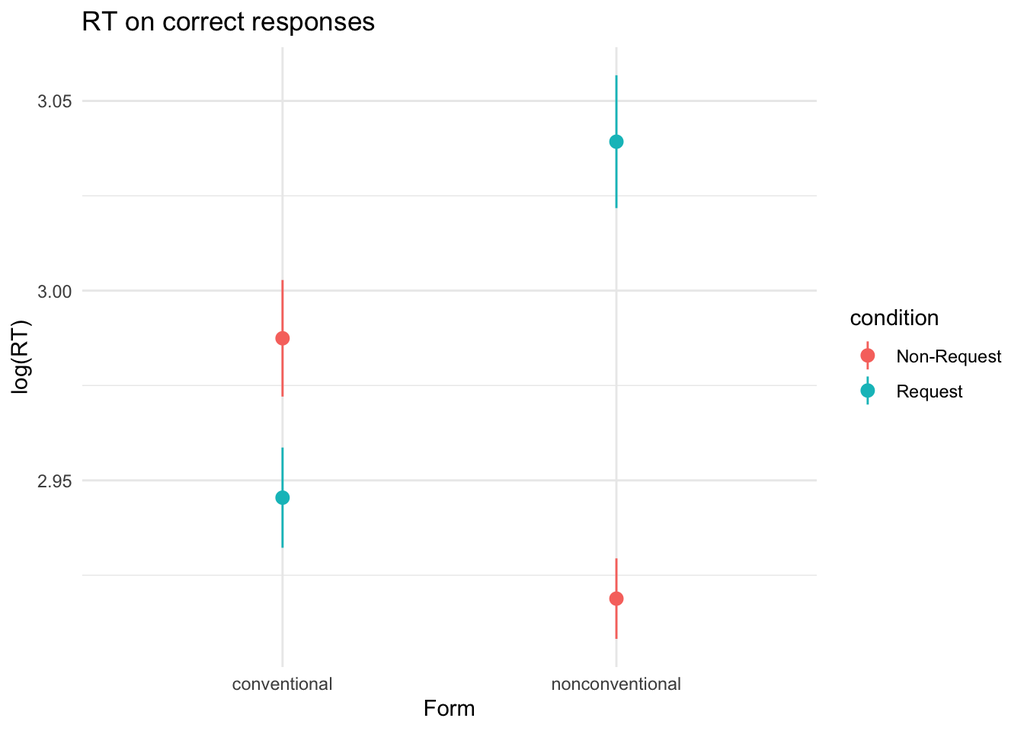

```r
df_merged_filtered = df_merged %>%
  filter(rt > 0) %>%
  mutate(log_rt = log10(rt))


df_merged_filtered %>%
  filter(correct == 1) %>%
  ggplot(aes(x = form,
             y = log_rt,
             color = condition)) +
  stat_summary (fun = function(x){mean(x)},
                fun.min = function(x){mean(x) - 1*sd(x)/sqrt(length(x))},
                fun.max = function(x){mean(x) + 1*sd(x)/sqrt(length(x))},
                geom= 'pointrange') +
  labs(title = "RT on correct responses",
       y = "log(RT)",
       x = "Form") +
  theme_minimal()
```

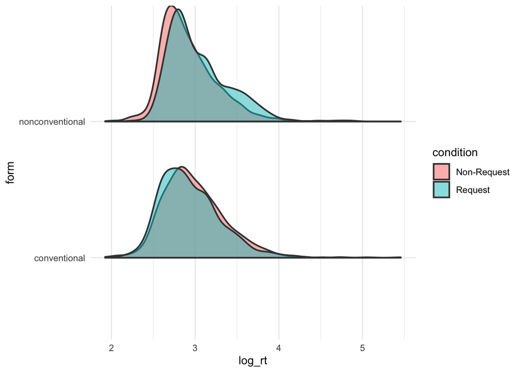

```r
df_merged_filtered %>%
  filter(correct == 1) %>%
  ggplot(aes(x = log_rt,
             y = form,
             fill = condition)) +
  geom_density_ridges2(aes(height = ..density..),
                       color=gray(0.25), alpha = 0.5,
                       scale=0.85, size=0.75, stat="density") +
  theme_minimal()
```

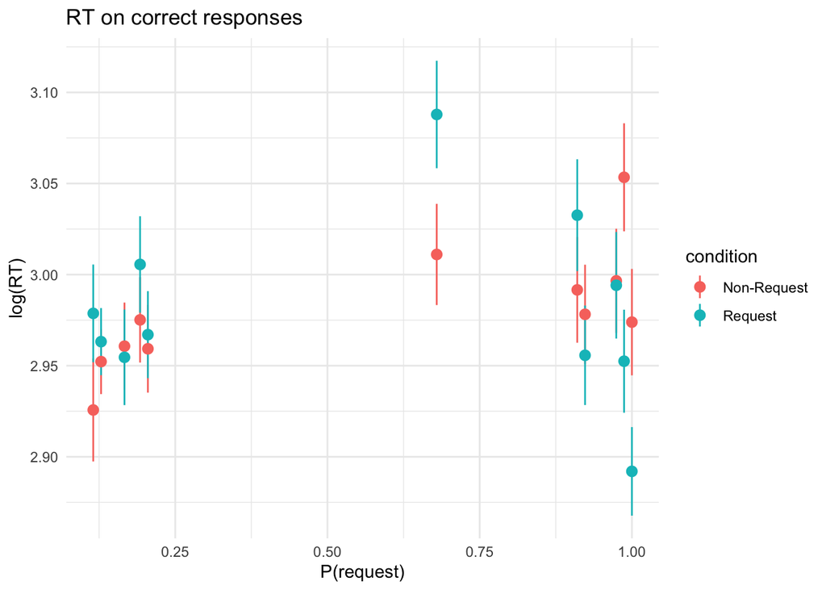

```r
df_merged_filtered %>%
  # filter(correct == 1) %>%
  ggplot(aes(x = mean_request,
             y = log_rt,
             color = condition)) +
  stat_summary (fun = function(x){mean(x)},
                fun.min = function(x){mean(x) - 1*sd(x)/sqrt(length(x))},
                fun.max = function(x){mean(x) + 1*sd(x)/sqrt(length(x))},
                geom= 'pointrange') +
  labs(title = "RT on correct responses",
       y = "log(RT)",
       x = "P(request)") +
  theme_minimal()
```

```r
m_full = lmer(data = filter(df_merged_filtered, correct == 1),
              log_rt ~ mean_request * Intent +
                (1 + Intent * mean_request | subject) + (1 | topic),
              control=lmerControl(optimizer="bobyqa"),
              REML = FALSE)
```

```
## boundary (singular) fit: see ?isSingular
```

```r
m_reduced = lmer(data = filter(df_merged_filtered, correct == 1),
              log_rt ~ mean_request + Intent +
                (1 + Intent * mean_request | subject) + (1 | topic),
              control=lmerControl(optimizer="bobyqa"),
              REML = FALSE)
```

```
## boundary (singular) fit: see ?isSingular
```

```r
anova(m_full, m_reduced)
```

```
## Data: filter(df_merged_filtered, correct == 1)
## Models:
## m_reduced: log_rt ~ mean_request + Intent + (1 + Intent * mean_request |
## m_reduced:     subject) + (1 | topic)
## m_full: log_rt ~ mean_request * Intent + (1 + Intent * mean_request |
## m_full:     subject) + (1 | topic)
##           npar    AIC    BIC  logLik deviance  Chisq Df Pr(>Chisq)
## m_reduced   15 1794.2 1883.2 -882.12   1764.2
## m_full      16 1780.0 1874.9 -874.00   1748.0 16.228  1  5.615e-05 ***
## ---
## Signif. codes:  0 '***' 0.001 '**' 0.01 '*' 0.05 '.' 0.1 ' ' 1
```

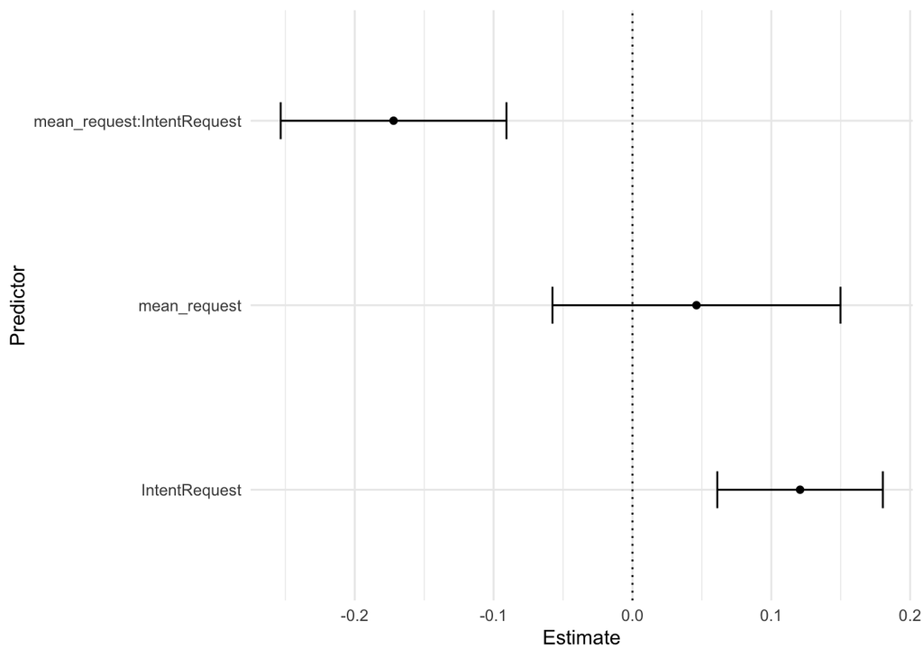

```r
df_tidy = broom.mixed::tidy(m_full)

df_tidy %>%
  filter(effect == "fixed") %>%
  filter(term != "(Intercept)") %>%
  ggplot(aes(x = term,
             y = estimate)) +
  geom_point() +
  coord_flip() +
  geom_hline(yintercept = 0, linetype = "dotted") +
  geom_errorbar(aes(ymin = estimate - 2*std.error,
                    ymax = estimate + 2*std.error),
                width=.2,
                position=position_dodge(.9)) +
  labs(x = "Predictor",
       y = "Estimate") +
  theme_minimal()
```